# Trabalho Final MQCP 2024.1

## Objeto

O tema central da apresentação é publicizar os resultados da pesquisa realizada sobre a influência da confiança nos partidos políticos na Institucionalização do Sistema Partidário, intitulado “*This is why we can’t have nice things:* o impacto da (des)confiança nos partidos para a Institucionalização do Sistema Partidário na América Latina”

## Objetivos

Questões de Pesquisa:

- Como a confiança nos partidos políticos afeta a Institucionalização do Sistema Partidário, operacionalizada pela volatilidade eleitoral, na América Latina?
- Qual a relação entre o controle da corrupção e a confiança nos partidos políticos?

## Contexto

Schattschneider (2017) cita que é impensável a existência da democracia sem partidos. Para entender os fenômenos que ocorrem nas democracias é essencial voltar-se para estudar o sistema partidário. O nível de estabilidade do sistema partidário, por sua vez, mostra-se de extrema importância para a estabilidade da democracia.

A estabilidade da competição eleitoral, uma das dimensões da Instituição do Sistema Partidário, é essencial para o estabelecimento rótulos partidários capazes de prover atalhos cognitivos para a tomada de decisão dos eleitores (Mainwaring e Torcal, 2006), por exemplo. Uma maior instabilidade na competição também é capaz de causar o enfraquecimento dos regimes democráticos (Mainwaring e Zoco, 2007).

## Método

## Coleta de Dados

**Dados de Confiança nos Partidos**

A variável de confiança nos partidos políticos foi coletada da base de dados do Latinobarômetro (de 1995 a 2005) e do AmericasBarometer/LAPOP (a partir de 2005).

Como estas duas pesquisas permitiam diferentes variações de respostas para a pergunta de confiança, foi feita uma transformação linear na escala de ambos estudos para que fosse possível a comparação entre eles.

De forma a equiparar a unidade de análise com a estudada pela volatilidade eleitoral, realizou-se a agregação das médias de confiança por país e ano do estudo.

## Coleta de Dados

**Outras variáveis**

Todas as outras variáveis utilizadas neste trabalho, foram obtidas no dataset *Replication Data for: Electoral Volatility in Latin America, 1932–2018* dos pesquisadores Scott Mainwaring e Yen-Pin Su, com acesso disponível via Harvard Dataverse.

A equivalência entre conceitos e variáveis da base de dados foi a seguinte:

- Corrupção: con_corruption (nível de controle da corrupção)
- Volatilidade: volatility, newparties e withinsv
- Identificação Partidária/Partidarismo: party_id
- Crescimento do PIB: gdp_growth1
- Número Efetivo de Partidos: enp

## Análise de Dados

Para entender a relação entre a corrupção e a confiança nos partidos políticos na América Latina, calculou-se o coeficiente de correlação de Spearman.

Esta técnica foi utilizada pela observação de uma assimetria na distribuição das observações da variável utilizada como proxy de corrupção.

De forma a testar a hipótese da existência da relação entre a confiança nos partidos políticos e a volatilidade na região, utilizou-se da técnica de regressão Estimação de Equações Generalizadas (GEE) com a especificação Auto-Regressiva de Ordem 1 (AR1).

A utilização deste método se deve pela intenção de capturar o efeito das mudanças nas variáveis independentes em relação à média dos países que compõem o dataset e não somente os seus efeitos em cada país individualmente.

## Resultados

## A confiança nos partidos políticos na América Latina

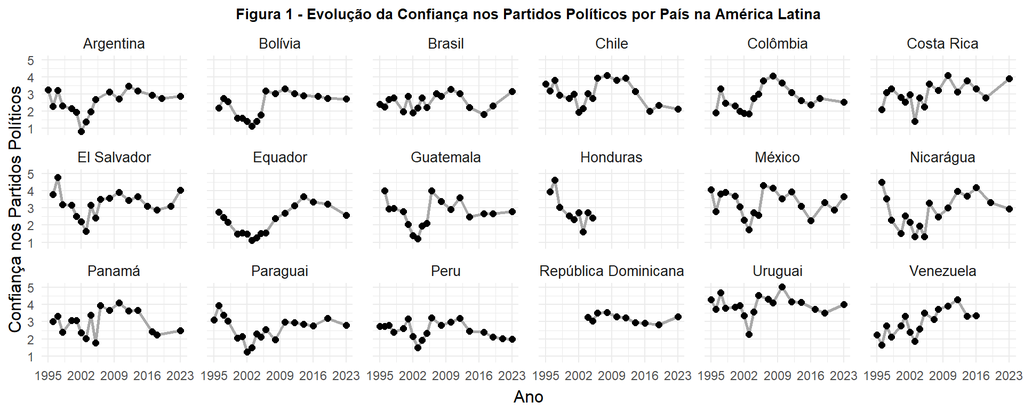

## A confiança nos partidos políticos na América Latina

Ao analisar individualmente, destacam-se o Equador, a Bolívia e o Peru como os países com maior desconfiança nos partidos políticos, enquanto El Salvador, o México e o Uruguai apresentam níveis mais elevados de confiança.

## A corrupção e a confiança nos partidos políticos

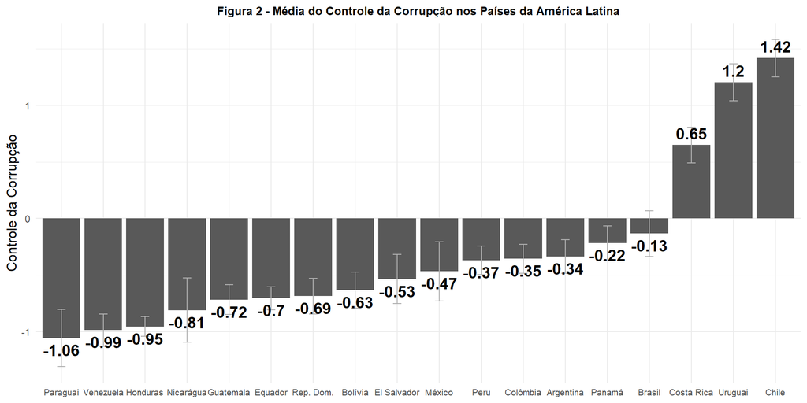

## A corrupção e a confiança nos partidos políticos

Em comparação ao índice de confiança, o índice de controle da corrupção apresenta uma menor variação nos dados de cada país, indicado pelos menores valores de desvio padrão. Ainda assim, a maioria dos países do estudo têm um nível de controle da corrupção considerado baixo.

Isto conversa com diversos achados da literatura que indicam um sentimento enraizado (entenda-se, com pouca variação) de corrupção generalizada nos países da América Latina, com exceção dos únicos casos que obtêm resultados positivos: Costa Rica, Uruguai e Chile (Rotberg, 2019; Canache e Allison, 2005).

## A corrupção e a confiança nos partidos políticos

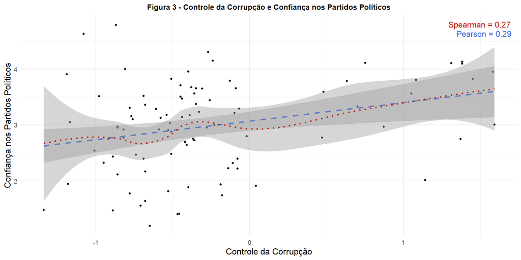

## A corrupção e a confiança nos partidos políticos

O resultado obtido é uma correlação positiva fraca de, aproximadamente, *0,27* para a correlação de Spearman e *0,29* para a correlação de Pearson. Esta baixa relação pode indicar que o controle da corrupção é um dos fatores que influenciam a confiança nos partidos dentre de uma gama de outros fatores.

Ceka (2013), ao analisar os países que haviam sido palco para regimes comunistas, observa que a competição partidária, a liberdade de imprensa, como influenciadores de uma maior suspeição em relação aos partidos políticos. Por outro lado, a igualdade econômica, a confiança interpessoal, a confiança na democracia e proximidade aos partidos políticos, agem como determinantes de uma maior confiança.

## A confiança nos partidos políticos e a volatilidade eleitoral

Tabela 1 - Resultados das Regressões (Modelo GEEAR1)

| Variáveis | Vol. Leg. Total | Vol. Pres. Total | Vol. Leg. Extra | Vol. Pres. Extra | Vol. Leg. Intra | Vol. Pres. Intra |
| --- | --- | --- | --- | --- | --- | --- |
| Intercepto | 3.827*** (0.295) | 4.726*** (0.168) | 3.712*** (0.591) | 5.521*** (0.596) | 3.077*** (0.288) | 2.797*** (0.361) |
| NEP | 0.005 (0.029) | 0.023 (0.02) | 0.004 (0.058) | -0.086 (0.064) | 0.01 (0.029) | 0.104*** (0.019) |
| Crescimento do PIB | -0.03* (0.013) | -0.039** (0.014) | -0.039 (0.038) | -0.116*** (0.03) | -0.017 (0.015) | 0.062 (0.043) |
| Identificação | -0.009** (0.003) | -0.013*** (0.003) | -0.005 (0.008) | -0.019* (0.008) | -0.013*** (0.003) | -0.009 (0.005) |
| Confiança | -0.075 (0.068) | -0.247*** (0.045) | -0.549*** (0.119) | -0.573*** (0.119) | 0.105 (0.076) | -0.012 (0.084) |

## A confiança nos partidos políticos e a volatilidade eleitoral

Ao todo foram 89 observações para cada modelo de volatilidade legislativa e 75 casos em cada modelo de volatilidade presidencial.

Os resultados parecem bastante promissores para a hipótese de trabalho elaborada. A confiança nos partidos exerce a maior influência absoluta para a diminuição da volatilidade presidencial e legislativa de novos partidos, além da volatilidade presidencial total.

No modelo com a volatilidade legislativa extrassistêmica, somente esta variável se mostrou significativa, indicando que a confiança nos partidos políticos teve um efeito mais significativo do que os outros fatores já estudados na literatura para controlar a ascensão eleitoral de novos competidores do sistema partidário.

## Conclusões

- Apesar da limitação do recorte temporal, o principal resultado encontrado foi a confirmação da hipótese de trabalho na dimensão extrassistêmica da volatilidade.
- Este achado aprofunda a literatura de Sistema Partidário por determinar o impacto entre a opinião pública e uma instituição política.
- Outro achado do presente trabalho foi a correlação fraca entre o controle da corrupção e a confiança no sistema partidário.
- Futuros estudos podem fornecer modelos mais robustos para os determinantes individuais da confiança nos partidos políticos latinoamericanos, semelhante ao que foi feito por Ceka (2013), não se limitando só à corrupção, e como eles interagem com o Sistema Partidário.

## Referências

CANACHE, Damarys; ALLISON, Michael E. Perceptions of political corruption in Latin American democracies. **Latin American Politics and Society**, v. 47, n. 3, p. 91-111, 2005.

CEKA, Besir. The perils of political competition: Explaining participation and trust in political parties in Eastern Europe. **Comparative Political Studies**, v. 46, n. 12, p. 1610-1635, 2013.

MAINWARING, Scott; ZOCO, Edurne. Political sequences and the stabilization of interparty competition: electoral volatility in old and new democracies. **Party Politics**, v. 13, n. 2, p. 155-178, 2007.

MAINWARING, Scott; TORCAL, Mariano. Party system institutionalization and party system theory after the third wave of democratization. **Handbook of Party Politics**, v. 11, n. 6, p. 204-227, 2006.

MAINWARING, SCOTT; SU, YEN-PIN, 2021, “Replication Data for: Electoral Volatility in Latin America, 1932–2018”, https://doi.org/10.7910/DVN/KVUKBF, Harvard Dataverse, V1, UNF:6:GSkBpSKk6SDR8S93C0i6SA== [fileUNF]

ROTBERG, Robert I.. The Corruption of Latin America. **Corruption In Latin America**, [S.L.], p. 1-25, 20 out. 2018. Springer International Publishing.

SCHATTSCHNEIDER, Elmer. Party government: American government in action. Routledge, 2017.